# Epilepsy & Brain Atrophy: Predictive Modeling

Aashi Sachania

```r
# install.packages("tidyverse")
# install.packages("moderndive")
library(tidyverse)
library(moderndive)
```

# Temporal Lobe Epilepsy and Hippocampus Size

The impact of epilepsy on the brain extends beyond individual seizures. Repeated seizure activity over time is associated with measurable reductions in hippocampal volume, a process known as neural atrophy. However, it remains unclear whether this degradation is symmetric. Specifically, it is uncertain whether the brain shrinks uniformly on both sides or if the hemisphere where seizures originate experiences greater atrophy. In this analysis, linear regression was used to model hippocampal volume as a function of time since diagnosis, enabling comparison of atrophy trajectories between hemispheres.

## Acquire Data

```r
epilepsy_dat <- read.csv("https://raw.githubusercontent.com/cgmr-asu/NEU290/main/EpilepsyHC.csv")
```

## Explore Data

```r
glimpse(epilepsy_dat)
```

```
## Rows: 90
## Columns: 4
## $ X               <int> 1, 2, 3, 4, 5, 6, 7, 8, 9, 10, 11, 12, 13, 14, 15, 16,…
## $ Years           <dbl> 33.838010, 39.844642, 18.855781, 6.080546, 7.835068, 2…
## $ IpsilateralHC   <dbl> 2.355614, 2.177067, 2.003562, 2.116303, 2.507545, 1.89…
## $ ContralateralHC <dbl> 2.158968, 2.554975, 2.200598, 2.440547, 2.565850, 2.31…
```

The variables in this data frame represent the number of years since a participant was diagnosed with epilepsy (Years), the volume of the Ipsilateral Hippocampus, the HC on the side where seizures originate, in cubic centimeters (IpsilateralHC) and the volume of the Contralateral Hippocampus, the HC on the side opposite to where seizures begin (ContralateralHC).

## Model Data

Two linear models were built to compare atrophy trajectories across hemispheres — one for the ipsilateral hippocampus and one for the contralateral hippocampus — to determine whether volume loss progresses equally on both sides or is concentrated on the seizure-origin side.

### Exploratory Visualization of Ipsilateral Hippocampal Volume

A scatterplot with a fitted regression line reveals the relationship between years since diagnosis and ipsilateral hippocampal volume.

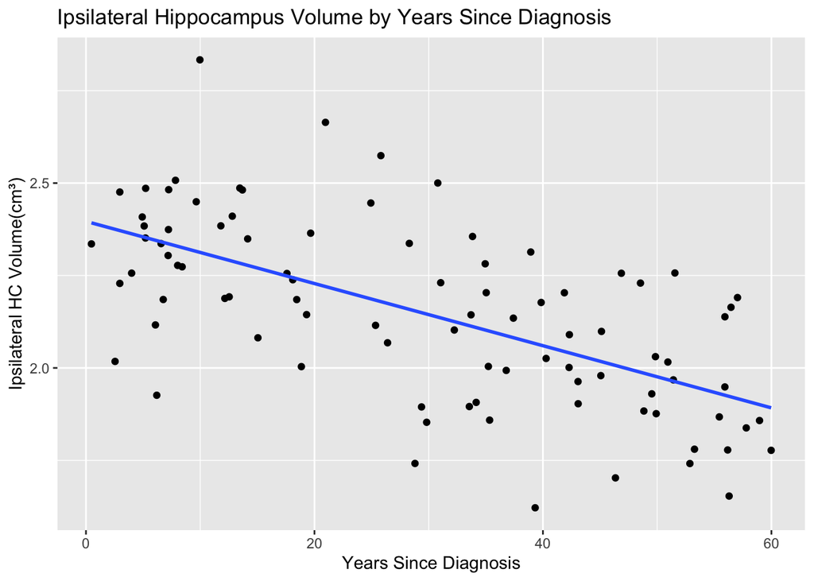

```r
epilepsy_dat %>%
  ggplot(aes(x = Years, y = IpsilateralHC)) +
  geom_point() +
  geom_smooth(method = "lm", se = FALSE) +
  labs(
    title = "Ipsilateral Hippocampus Volume by Years Since Diagnosis",
    x = "Years Since Diagnosis",
    y = "Ipsilateral HC Volume(cm³)"
  )
```